# Skaha Lake

##### Boron Total (fl. conc.)

✓

[BC Aquatic Life Guideline](https://www2.gov.bc.ca/gov/content/environment/air-land-water/water/water-quality/water-quality-guidelines/approved-water-quality-guidelines) · Long-term chronic (Upper Limit) Aquatic Life - Freshwater

≤1.2 mg/L

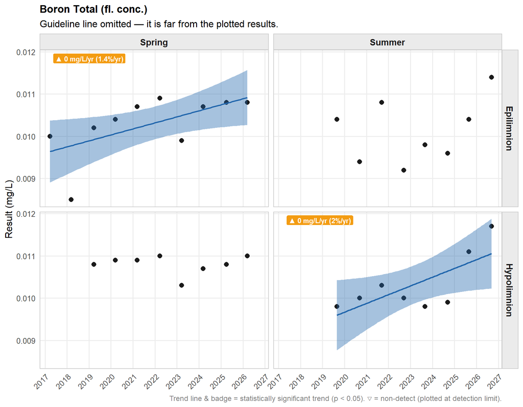

**▶ Summary Statistics Table**

**Skaha Lake**

Boron Total (fl. conc.) (mg/L)

| N | Min<sup>1</sup> | 10th %ile | Median | Mean | 90th %ile | Max |
| --- | --- | --- | --- | --- | --- | --- |
| Hypolimnion — Summer |  |  |  |  |  |  |
| 8 | 0.0098 | 0.0098 | 0.01 | 0.0103 | 0.0113 | 0.0117 |
| Hypolimnion — Spring |  |  |  |  |  |  |
| 8 | 0.0103 | 0.0106 | 0.0108 | 0.0108 | 0.011 | 0.011 |
| Epilimnion — Summer |  |  |  |  |  |  |
| 8 | 0.0092 | 0.00934 | 0.0101 | 0.0101 | 0.011 | 0.0114 |
| Epilimnion — Spring |  |  |  |  |  |  |
| 11 | 0.0085 | 0.0099 | 0.0107 | 0.0103 | 0.0108 | 0.0109 |

<sup>1</sup> < indicates non-detect; value shown is the detection limit.

##### Cadmium Total (fl. conc.)

—

No simple [BC Aquatic Life Guideline](https://www2.gov.bc.ca/gov/content?id=044DD64C7E24415D83D07430964113C9) available for this parameter

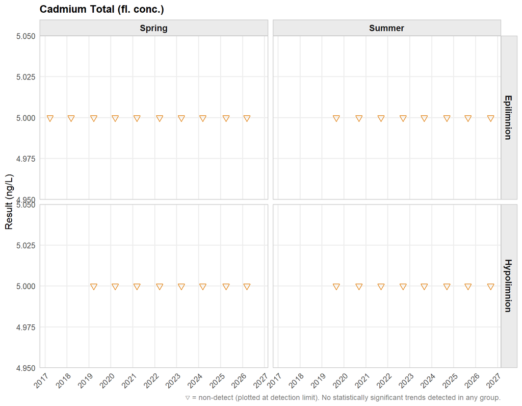

**▶ Summary Statistics Table**

**Skaha Lake**

Cadmium Total (fl. conc.) (ng/L)

| N | Min<sup>1</sup> | 10th %ile | Median | Mean | 90th %ile | Max |
| --- | --- | --- | --- | --- | --- | --- |
| Hypolimnion — Summer |  |  |  |  |  |  |
| 8 | <5 | <5 | <5 | <5 | <5 | <5 |
| Hypolimnion — Spring |  |  |  |  |  |  |
| 8 | <5 | <5 | <5 | <5 | <5 | <5 |
| Epilimnion — Summer |  |  |  |  |  |  |
| 8 | <5 | <5 | <5 | <5 | <5 | <5 |
| Epilimnion — Spring |  |  |  |  |  |  |
| 11 | <5 | <5 | <5 | <5 | <5 | <5 |

<sup>1</sup> < indicates non-detect; value shown is the detection limit.

##### Calcium Total (fl. conc.)

—

No simple [BC Aquatic Life Guideline](https://www2.gov.bc.ca/gov/content?id=044DD64C7E24415D83D07430964113C9) available for this parameter

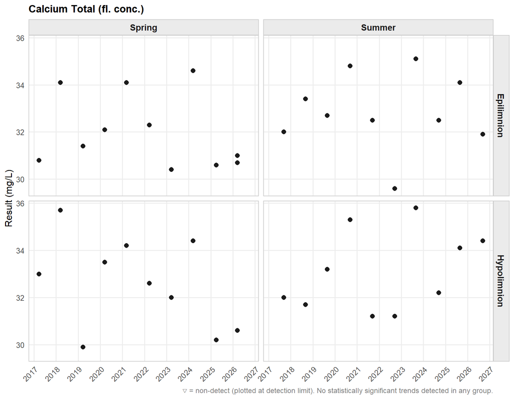

**▶ Summary Statistics Table**

**Skaha Lake**

Calcium Total (fl. conc.) (mg/L)

| N | Min<sup>1</sup> | 10th %ile | Median | Mean | 90th %ile | Max |
| --- | --- | --- | --- | --- | --- | --- |
| Hypolimnion — Summer |  |  |  |  |  |  |
| 10 | 31.2 | 31.2 | 32.7 | 33.1 | 35.3 | 35.8 |
| Hypolimnion — Spring |  |  |  |  |  |  |
| 10 | 29.9 | 30.2 | 32.8 | 32.6 | 34.5 | 35.7 |
| Epilimnion — Summer |  |  |  |  |  |  |
| 10 | 29.6 | 31.7 | 32.6 | 32.9 | 34.8 | 35.1 |
| Epilimnion — Spring |  |  |  |  |  |  |
| 11 | 30.4 | 30.6 | 31.4 | 32 | 34.1 | 34.6 |

<sup>1</sup> < indicates non-detect; value shown is the detection limit.

##### Chromium Total (fl. conc.)

—

No simple [BC Aquatic Life Guideline](https://www2.gov.bc.ca/gov/content?id=044DD64C7E24415D83D07430964113C9) available for this parameter

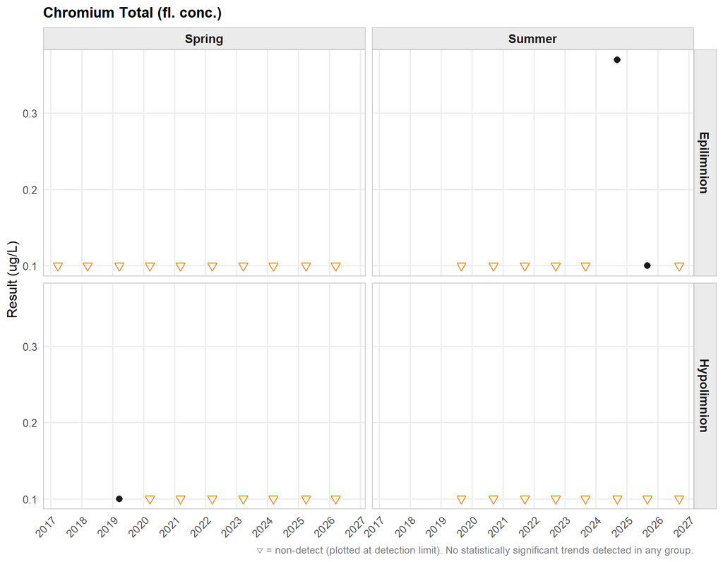

**▶ Summary Statistics Table**

**Skaha Lake**

Chromium Total (fl. conc.) (ug/L)

| N | Min<sup>1</sup> | 10th %ile | Median | Mean | 90th %ile | Max |
| --- | --- | --- | --- | --- | --- | --- |
| Hypolimnion — Summer |  |  |  |  |  |  |
| 8 | <0.1 | <0.1 | <0.1 | <0.1 | <0.1 | <0.1 |
| Hypolimnion — Spring |  |  |  |  |  |  |
| 8 | <0.1 | <0.1 | <0.1 | <0.1 | <0.1 | <0.1 |
| Epilimnion — Summer |  |  |  |  |  |  |
| 8 | <0.1 | <0.1 | <0.1 | 0.134 | 0.181 | 0.37 |
| Epilimnion — Spring |  |  |  |  |  |  |
| 11 | <0.1 | <0.1 | <0.1 | <0.1 | <0.1 | <0.1 |

<sup>1</sup> < indicates non-detect; value shown is the detection limit.

##### Cobalt Total (fl. conc.)

—

No simple [BC Aquatic Life Guideline](https://www2.gov.bc.ca/gov/content?id=044DD64C7E24415D83D07430964113C9) available for this parameter

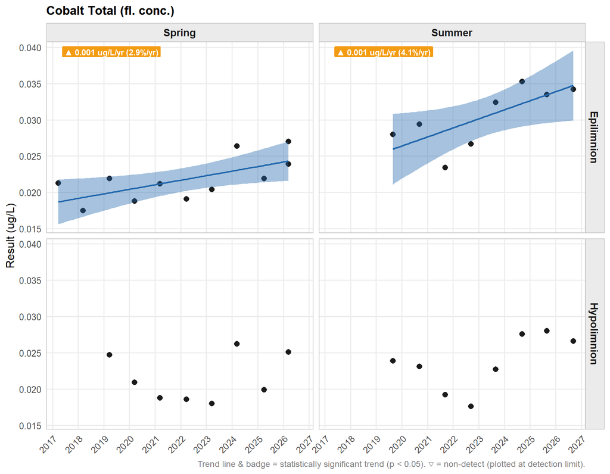

**▶ Summary Statistics Table**

**Skaha Lake**

Cobalt Total (fl. conc.) (ug/L)

| N | Min<sup>1</sup> | 10th %ile | Median | Mean | 90th %ile | Max |
| --- | --- | --- | --- | --- | --- | --- |
| Hypolimnion — Summer |  |  |  |  |  |  |
| 8 | 0.0176 | 0.0187 | 0.0235 | 0.0236 | 0.0277 | 0.028 |
| Hypolimnion — Spring |  |  |  |  |  |  |
| 8 | 0.018 | 0.0184 | 0.0204 | 0.0215 | 0.0254 | 0.0262 |
| Epilimnion — Summer |  |  |  |  |  |  |
| 8 | 0.0234 | 0.0257 | 0.0309 | 0.0304 | 0.0345 | 0.0353 |
| Epilimnion — Spring |  |  |  |  |  |  |
| 11 | 0.0175 | 0.0188 | 0.0213 | 0.0218 | 0.0264 | 0.027 |

<sup>1</sup> < indicates non-detect; value shown is the detection limit.

##### Copper Total (fl. conc.)

—

No simple [BC Aquatic Life Guideline](https://www2.gov.bc.ca/gov/content?id=044DD64C7E24415D83D07430964113C9) available for this parameter

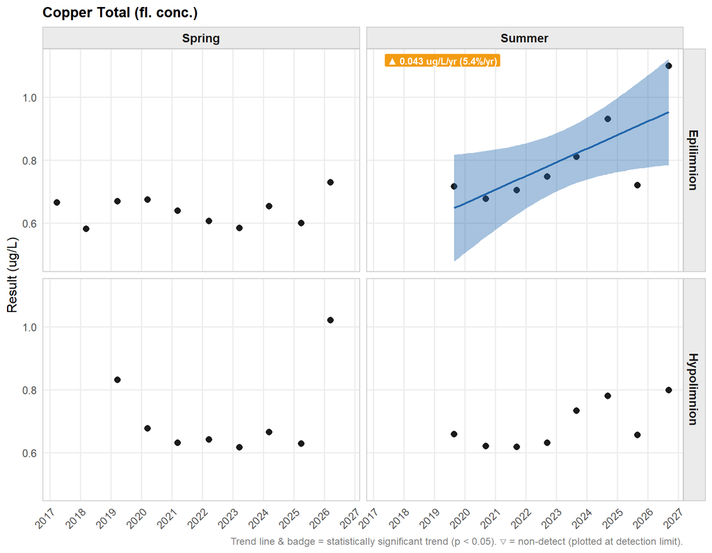

**▶ Summary Statistics Table**

**Skaha Lake**

Copper Total (fl. conc.) (ug/L)

| N | Min<sup>1</sup> | 10th %ile | Median | Mean | 90th %ile | Max |
| --- | --- | --- | --- | --- | --- | --- |
| Hypolimnion — Summer |  |  |  |  |  |  |
| 8 | 0.618 | 0.62 | 0.658 | 0.687 | 0.785 | 0.798 |
| Hypolimnion — Spring |  |  |  |  |  |  |
| 8 | 0.617 | 0.625 | 0.653 | 0.714 | 0.888 | 1.02 |
| Epilimnion — Summer |  |  |  |  |  |  |
| 8 | 0.678 | 0.697 | 0.734 | 0.801 | 0.982 | 1.1 |
| Epilimnion — Spring |  |  |  |  |  |  |
| 11 | 0.582 | 0.584 | 0.654 | 0.649 | 0.73 | 0.73 |

<sup>1</sup> < indicates non-detect; value shown is the detection limit.

##### Iron Total (fl. conc.)

—

No simple [BC Aquatic Life Guideline](https://www2.gov.bc.ca/gov/content?id=044DD64C7E24415D83D07430964113C9) available for this parameter

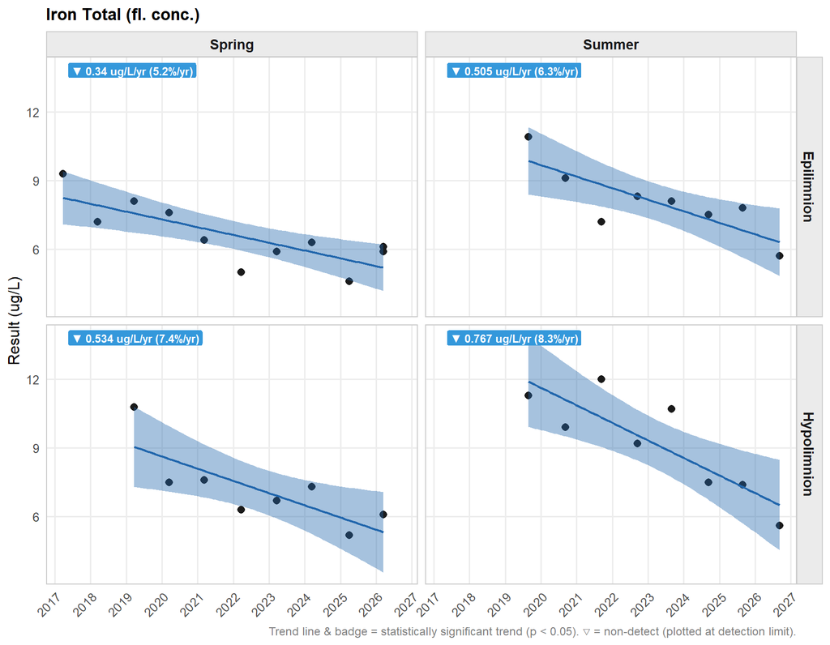

**▶ Summary Statistics Table**

**Skaha Lake**

Iron Total (fl. conc.) (ug/L)

| N | Min<sup>1</sup> | 10th %ile | Median | Mean | 90th %ile | Max |
| --- | --- | --- | --- | --- | --- | --- |
| Hypolimnion — Summer |  |  |  |  |  |  |
| 8 | 5.6 | 6.86 | 9.55 | 9.2 | 11.5 | 12 |
| Hypolimnion — Spring |  |  |  |  |  |  |
| 8 | 5.2 | 5.83 | 7 | 7.19 | 8.56 | 10.8 |
| Epilimnion — Summer |  |  |  |  |  |  |
| 8 | 5.7 | 6.75 | 7.95 | 8.07 | 9.64 | 10.9 |
| Epilimnion — Spring |  |  |  |  |  |  |
| 11 | 4.6 | 5 | 6.3 | 6.58 | 8.1 | 9.3 |

<sup>1</sup> < indicates non-detect; value shown is the detection limit.

##### Lead Total (fl. conc.)

—

No simple [BC Aquatic Life Guideline](https://www2.gov.bc.ca/gov/content?id=044DD64C7E24415D83D07430964113C9) available for this parameter

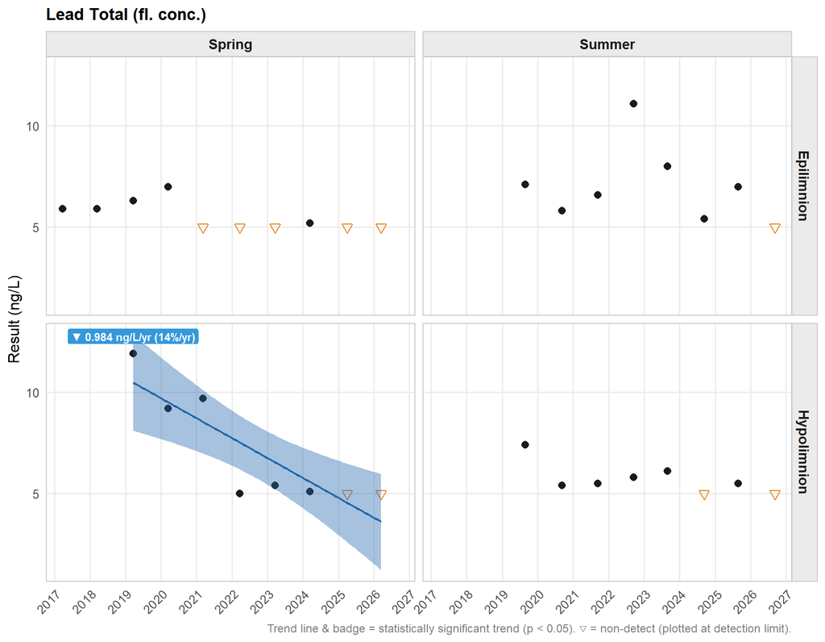

**▶ Summary Statistics Table**

**Skaha Lake**

Lead Total (fl. conc.) (ng/L)

| N | Min<sup>1</sup> | 10th %ile | Median | Mean | 90th %ile | Max |
| --- | --- | --- | --- | --- | --- | --- |
| Hypolimnion — Summer |  |  |  |  |  |  |
| 8 | <5 | <5 | 5.5 | 5.71 | 6.49 | 7.4 |
| Hypolimnion — Spring |  |  |  |  |  |  |
| 8 | <5 | <5 | 5.25 | 7.04 | 10.4 | 11.9 |
| Epilimnion — Summer |  |  |  |  |  |  |
| 8 | <5 | 5.28 | 6.8 | 7 | 8.93 | 11.1 |
| Epilimnion — Spring |  |  |  |  |  |  |
| 11 | <5 | <5 | <5 | 5.48 | 6.3 | 7 |

<sup>1</sup> < indicates non-detect; value shown is the detection limit.

##### Lithium Total (fl. conc.)

—

No simple [BC Aquatic Life Guideline](https://www2.gov.bc.ca/gov/content?id=044DD64C7E24415D83D07430964113C9) available for this parameter

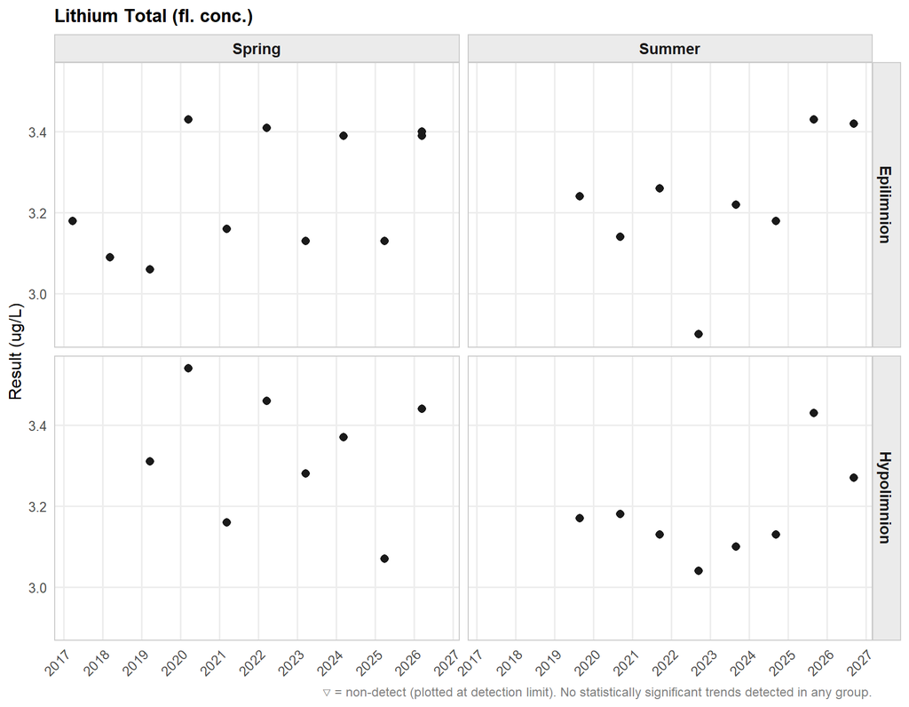

**▶ Summary Statistics Table**

**Skaha Lake**

Lithium Total (fl. conc.) (ug/L)

| N | Min<sup>1</sup> | 10th %ile | Median | Mean | 90th %ile | Max |
| --- | --- | --- | --- | --- | --- | --- |
| Hypolimnion — Summer |  |  |  |  |  |  |
| 8 | 3.04 | 3.08 | 3.15 | 3.18 | 3.32 | 3.43 |
| Hypolimnion — Spring |  |  |  |  |  |  |
| 8 | 3.07 | 3.13 | 3.34 | 3.33 | 3.48 | 3.54 |
| Epilimnion — Summer |  |  |  |  |  |  |
| 8 | 2.9 | 3.07 | 3.23 | 3.22 | 3.42 | 3.43 |
| Epilimnion — Spring |  |  |  |  |  |  |
| 11 | 3.06 | 3.09 | 3.18 | 3.25 | 3.41 | 3.43 |

<sup>1</sup> < indicates non-detect; value shown is the detection limit.

##### Magnesium Total (fl. conc.)

—

No simple [BC Aquatic Life Guideline](https://www2.gov.bc.ca/gov/content?id=044DD64C7E24415D83D07430964113C9) available for this parameter

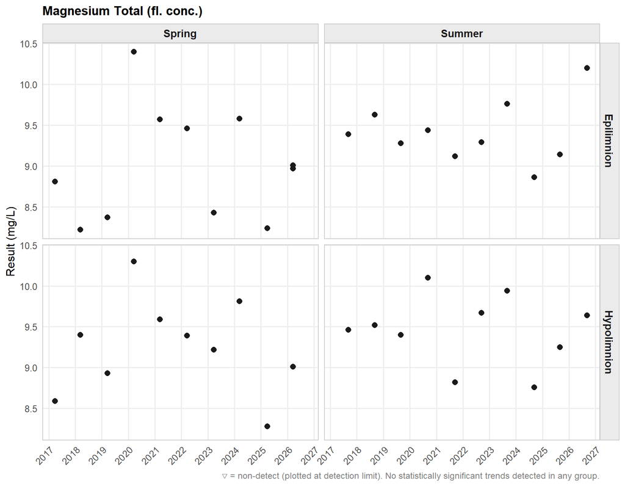

**▶ Summary Statistics Table**

**Skaha Lake**

Magnesium Total (fl. conc.) (mg/L)

| N | Min<sup>1</sup> | 10th %ile | Median | Mean | 90th %ile | Max |
| --- | --- | --- | --- | --- | --- | --- |
| Hypolimnion — Summer |  |  |  |  |  |  |
| 10 | 8.76 | 8.81 | 9.49 | 9.46 | 9.96 | 10.1 |
| Hypolimnion — Spring |  |  |  |  |  |  |
| 10 | 8.28 | 8.56 | 9.3 | 9.25 | 9.86 | 10.3 |
| Epilimnion — Summer |  |  |  |  |  |  |
| 10 | 8.86 | 9.09 | 9.34 | 9.41 | 9.8 | 10.2 |
| Epilimnion — Spring |  |  |  |  |  |  |
| 11 | 8.22 | 8.24 | 8.97 | 9.01 | 9.58 | 10.4 |

<sup>1</sup> < indicates non-detect; value shown is the detection limit.

##### Manganese Total (fl. conc.)

—

No simple [BC Aquatic Life Guideline](https://www2.gov.bc.ca/gov/content?id=044DD64C7E24415D83D07430964113C9) available for this parameter

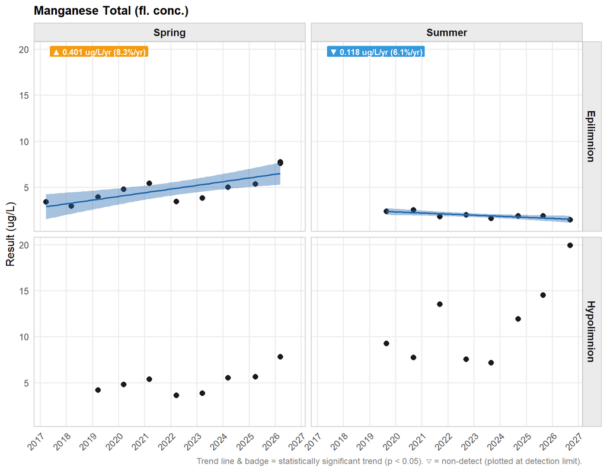

**▶ Summary Statistics Table**

**Skaha Lake**

Manganese Total (fl. conc.) (ug/L)

| N | Min<sup>1</sup> | 10th %ile | Median | Mean | 90th %ile | Max |
| --- | --- | --- | --- | --- | --- | --- |
| Hypolimnion — Summer |  |  |  |  |  |  |
| 8 | 7.14 | 7.42 | 10.6 | 11.4 | 16.1 | 19.9 |
| Hypolimnion — Spring |  |  |  |  |  |  |
| 8 | 3.62 | 3.77 | 5.07 | 5.09 | 6.29 | 7.79 |
| Epilimnion — Summer |  |  |  |  |  |  |
| 8 | 1.46 | 1.56 | 1.88 | 1.94 | 2.43 | 2.52 |
| Epilimnion — Spring |  |  |  |  |  |  |
| 11 | 2.96 | 3.39 | 4.77 | 4.86 | 7.61 | 7.73 |

<sup>1</sup> < indicates non-detect; value shown is the detection limit.

##### Molybdenum Total (fl. conc.)

✓

[BC Aquatic Life Guideline](https://www2.gov.bc.ca/gov/content/environment/air-land-water/water/water-quality/water-quality-guidelines/approved-water-quality-guidelines) · Long-term chronic (Upper Limit) Aquatic Life - Freshwater

≤7600 ug/L

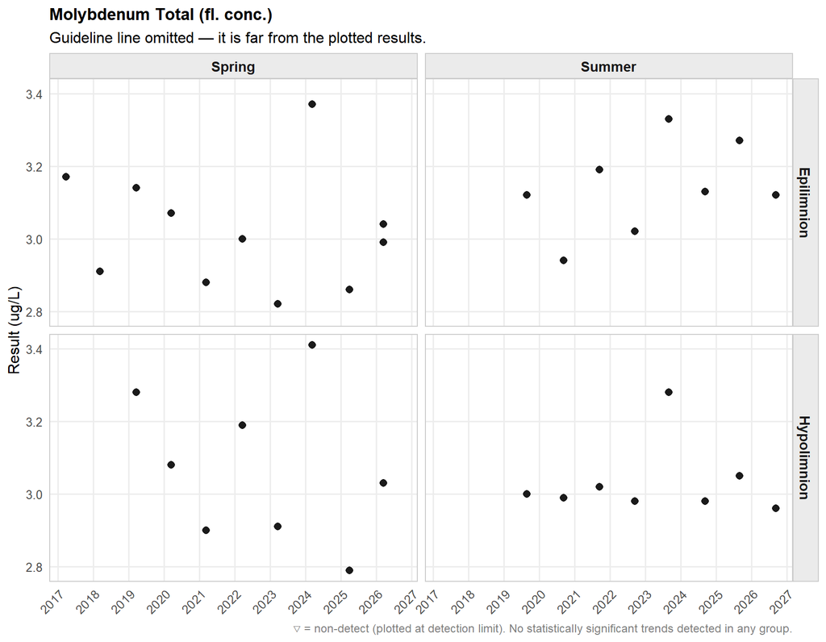

**▶ Summary Statistics Table**

**Skaha Lake**

Molybdenum Total (fl. conc.) (ug/L)

| N | Min<sup>1</sup> | 10th %ile | Median | Mean | 90th %ile | Max |
| --- | --- | --- | --- | --- | --- | --- |
| Hypolimnion — Summer |  |  |  |  |  |  |
| 8 | 2.96 | 2.97 | 3 | 3.03 | 3.12 | 3.28 |
| Hypolimnion — Spring |  |  |  |  |  |  |
| 8 | 2.79 | 2.87 | 3.06 | 3.07 | 3.32 | 3.41 |
| Epilimnion — Summer |  |  |  |  |  |  |
| 8 | 2.94 | 3 | 3.12 | 3.14 | 3.29 | 3.33 |
| Epilimnion — Spring |  |  |  |  |  |  |
| 11 | 2.82 | 2.86 | 3 | 3.02 | 3.17 | 3.37 |

<sup>1</sup> < indicates non-detect; value shown is the detection limit.

##### Nickel Total (fl. conc.)

—

No simple [BC Aquatic Life Guideline](https://www2.gov.bc.ca/gov/content?id=044DD64C7E24415D83D07430964113C9) available for this parameter

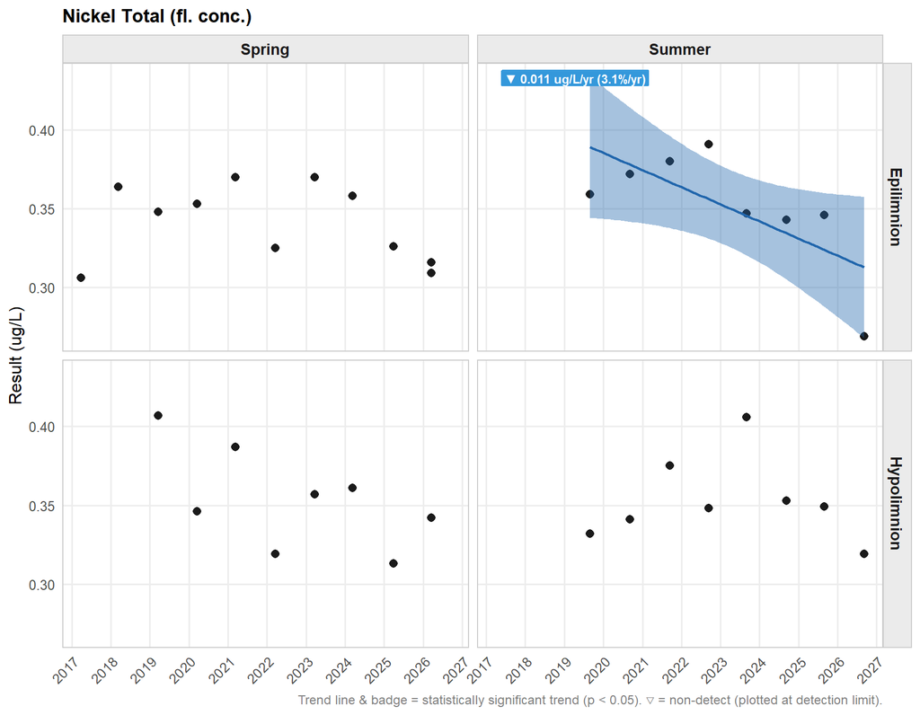

**▶ Summary Statistics Table**

**Skaha Lake**

Nickel Total (fl. conc.) (ug/L)

| N | Min<sup>1</sup> | 10th %ile | Median | Mean | 90th %ile | Max |
| --- | --- | --- | --- | --- | --- | --- |
| Hypolimnion — Summer |  |  |  |  |  |  |
| 8 | 0.319 | 0.328 | 0.349 | 0.353 | 0.384 | 0.406 |
| Hypolimnion — Spring |  |  |  |  |  |  |
| 8 | 0.313 | 0.317 | 0.352 | 0.354 | 0.393 | 0.407 |
| Epilimnion — Summer |  |  |  |  |  |  |
| 8 | 0.269 | 0.321 | 0.353 | 0.351 | 0.383 | 0.391 |
| Epilimnion — Spring |  |  |  |  |  |  |
| 11 | 0.306 | 0.309 | 0.348 | 0.34 | 0.37 | 0.37 |

<sup>1</sup> < indicates non-detect; value shown is the detection limit.

##### Potassium Total (fl. conc.)

—

No simple [BC Aquatic Life Guideline](https://www2.gov.bc.ca/gov/content?id=044DD64C7E24415D83D07430964113C9) available for this parameter

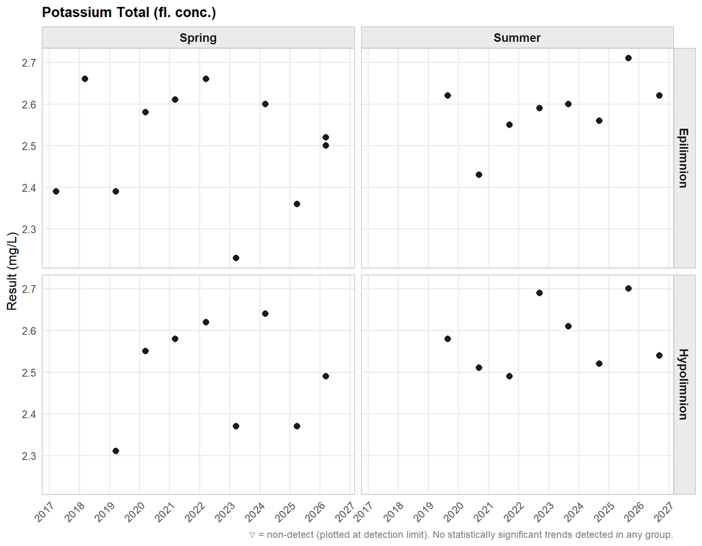

**▶ Summary Statistics Table**

**Skaha Lake**

Potassium Total (fl. conc.) (mg/L)

| N | Min<sup>1</sup> | 10th %ile | Median | Mean | 90th %ile | Max |
| --- | --- | --- | --- | --- | --- | --- |
| Hypolimnion — Summer |  |  |  |  |  |  |
| 8 | 2.49 | 2.5 | 2.56 | 2.58 | 2.69 | 2.7 |
| Hypolimnion — Spring |  |  |  |  |  |  |
| 8 | 2.31 | 2.35 | 2.52 | 2.49 | 2.63 | 2.64 |
| Epilimnion — Summer |  |  |  |  |  |  |
| 8 | 2.43 | 2.51 | 2.6 | 2.58 | 2.65 | 2.71 |
| Epilimnion — Spring |  |  |  |  |  |  |
| 11 | 2.23 | 2.36 | 2.52 | 2.5 | 2.66 | 2.66 |

<sup>1</sup> < indicates non-detect; value shown is the detection limit.

##### Selenium Total (fl. conc.)

✓

[BC Aquatic Life Guideline](https://www2.gov.bc.ca/gov/content/environment/air-land-water/water/water-quality/water-quality-guidelines/approved-water-quality-guidelines) · Long-term chronic (Upper Limit) Aquatic Life - Freshwater

≤2 ug/L

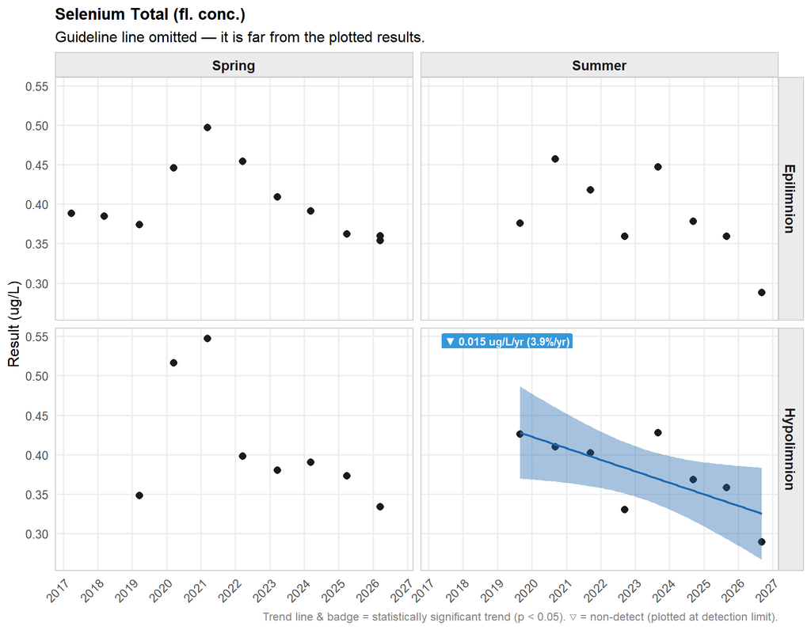

**▶ Summary Statistics Table**

**Skaha Lake**

Selenium Total (fl. conc.) (ug/L)

| N | Min<sup>1</sup> | 10th %ile | Median | Mean | 90th %ile | Max |
| --- | --- | --- | --- | --- | --- | --- |
| Hypolimnion — Summer |  |  |  |  |  |  |
| 8 | 0.289 | 0.318 | 0.385 | 0.376 | 0.427 | 0.428 |
| Hypolimnion — Spring |  |  |  |  |  |  |
| 8 | 0.334 | 0.344 | 0.385 | 0.411 | 0.525 | 0.547 |
| Epilimnion — Summer |  |  |  |  |  |  |
| 8 | 0.288 | 0.338 | 0.377 | 0.385 | 0.45 | 0.457 |
| Epilimnion — Spring |  |  |  |  |  |  |
| 11 | 0.354 | 0.36 | 0.388 | 0.402 | 0.454 | 0.497 |

<sup>1</sup> < indicates non-detect; value shown is the detection limit.

##### Silicon Total (fl. conc.)

—

No simple [BC Aquatic Life Guideline](https://www2.gov.bc.ca/gov/content?id=044DD64C7E24415D83D07430964113C9) available for this parameter

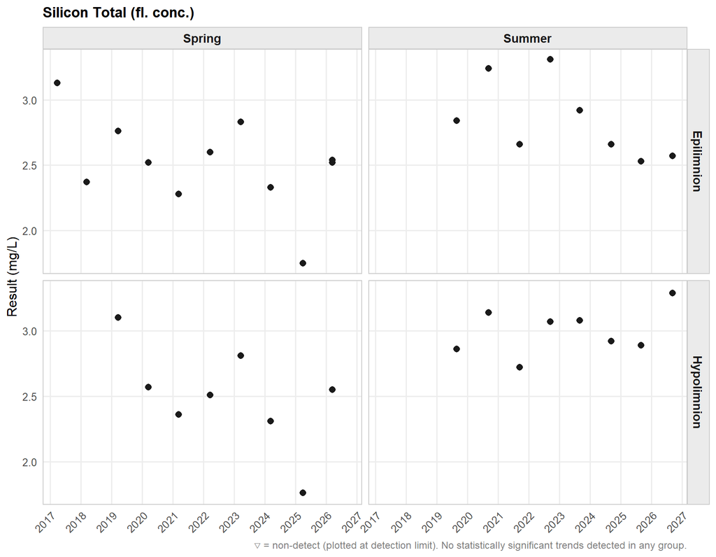

**▶ Summary Statistics Table**

**Skaha Lake**

Silicon Total (fl. conc.) (mg/L)

| N | Min<sup>1</sup> | 10th %ile | Median | Mean | 90th %ile | Max |
| --- | --- | --- | --- | --- | --- | --- |
| Hypolimnion — Summer |  |  |  |  |  |  |
| 8 | 2.72 | 2.82 | 3 | 3 | 3.19 | 3.29 |
| Hypolimnion — Spring |  |  |  |  |  |  |
| 8 | 1.76 | 2.14 | 2.53 | 2.5 | 2.9 | 3.1 |
| Epilimnion — Summer |  |  |  |  |  |  |
| 8 | 2.53 | 2.56 | 2.75 | 2.84 | 3.26 | 3.31 |
| Epilimnion — Spring |  |  |  |  |  |  |
| 11 | 1.75 | 2.28 | 2.52 | 2.51 | 2.83 | 3.13 |

<sup>1</sup> < indicates non-detect; value shown is the detection limit.

##### Silver Total (fl. conc.)

✓

[BC Aquatic Life Guideline](https://www2.gov.bc.ca/gov/content/environment/air-land-water/water/water-quality/water-quality-guidelines/approved-water-quality-guidelines) · Long-term chronic (Upper Limit) Aquatic Life - Freshwater

≤120 ng/L

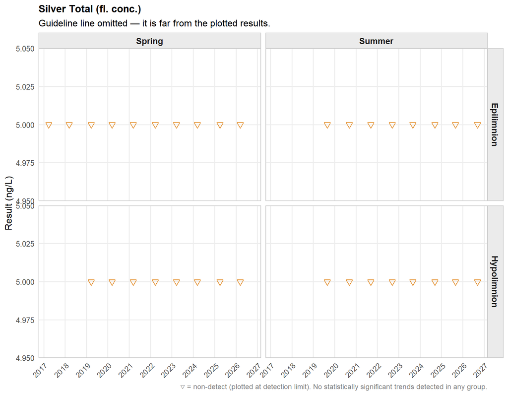

**▶ Summary Statistics Table**

**Skaha Lake**

Silver Total (fl. conc.) (ng/L)

| N | Min<sup>1</sup> | 10th %ile | Median | Mean | 90th %ile | Max |
| --- | --- | --- | --- | --- | --- | --- |
| Hypolimnion — Summer |  |  |  |  |  |  |
| 8 | <5 | <5 | <5 | <5 | <5 | <5 |
| Hypolimnion — Spring |  |  |  |  |  |  |
| 8 | <5 | <5 | <5 | <5 | <5 | <5 |
| Epilimnion — Summer |  |  |  |  |  |  |
| 8 | <5 | <5 | <5 | <5 | <5 | <5 |
| Epilimnion — Spring |  |  |  |  |  |  |
| 11 | <5 | <5 | <5 | <5 | <5 | <5 |

<sup>1</sup> < indicates non-detect; value shown is the detection limit.

##### Sodium Total (fl. conc.)

—

No simple [BC Aquatic Life Guideline](https://www2.gov.bc.ca/gov/content?id=044DD64C7E24415D83D07430964113C9) available for this parameter

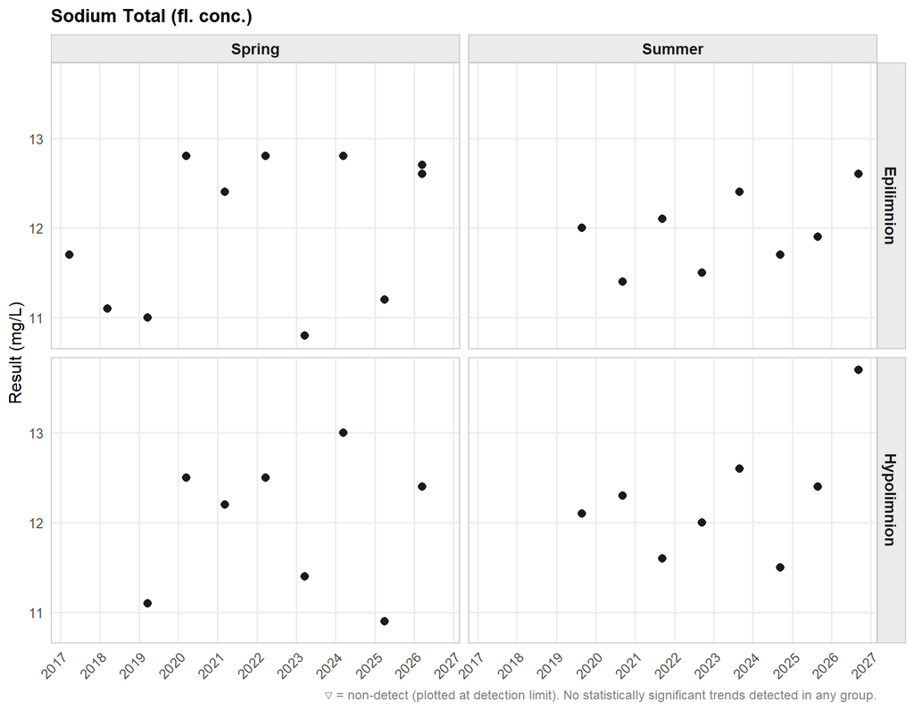

**▶ Summary Statistics Table**

**Skaha Lake**

Sodium Total (fl. conc.) (mg/L)

| N | Min<sup>1</sup> | 10th %ile | Median | Mean | 90th %ile | Max |
| --- | --- | --- | --- | --- | --- | --- |
| Hypolimnion — Summer |  |  |  |  |  |  |
| 8 | 11.5 | 11.6 | 12.2 | 12.3 | 12.9 | 13.7 |
| Hypolimnion — Spring |  |  |  |  |  |  |
| 8 | 10.9 | 11 | 12.3 | 12 | 12.6 | 13 |
| Epilimnion — Summer |  |  |  |  |  |  |
| 8 | 11.4 | 11.5 | 12 | 12 | 12.5 | 12.6 |
| Epilimnion — Spring |  |  |  |  |  |  |
| 11 | 10.8 | 11 | 12.4 | 12 | 12.8 | 12.8 |

<sup>1</sup> < indicates non-detect; value shown is the detection limit.

##### Strontium Total (fl. conc.)

—

No simple [BC Aquatic Life Guideline](https://www2.gov.bc.ca/gov/content?id=044DD64C7E24415D83D07430964113C9) available for this parameter

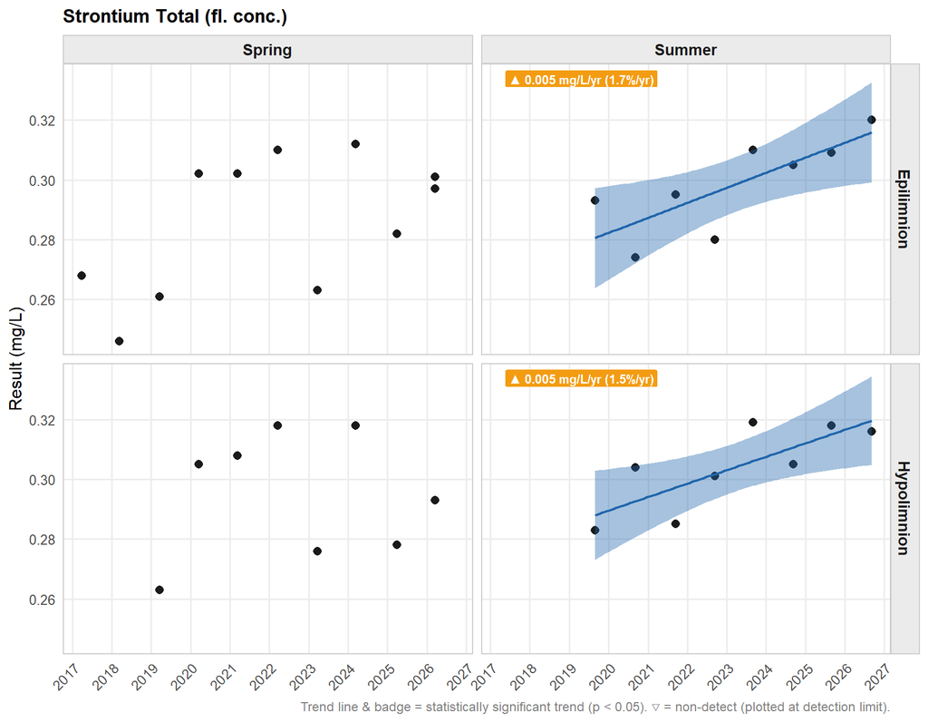

**▶ Summary Statistics Table**

**Skaha Lake**

Strontium Total (fl. conc.) (mg/L)

| N | Min<sup>1</sup> | 10th %ile | Median | Mean | 90th %ile | Max |
| --- | --- | --- | --- | --- | --- | --- |
| Hypolimnion — Summer |  |  |  |  |  |  |
| 8 | 0.283 | 0.284 | 0.304 | 0.304 | 0.318 | 0.319 |
| Hypolimnion — Spring |  |  |  |  |  |  |
| 8 | 0.263 | 0.272 | 0.299 | 0.295 | 0.318 | 0.318 |
| Epilimnion — Summer |  |  |  |  |  |  |
| 8 | 0.274 | 0.278 | 0.3 | 0.298 | 0.313 | 0.32 |
| Epilimnion — Spring |  |  |  |  |  |  |
| 11 | 0.246 | 0.261 | 0.297 | 0.286 | 0.31 | 0.312 |

<sup>1</sup> < indicates non-detect; value shown is the detection limit.

##### Thallium Total (fl. conc.)

✓

[BC Aquatic Life Guideline](https://www2.gov.bc.ca/gov/content/environment/air-land-water/water/water-quality/water-quality-guidelines/approved-water-quality-guidelines) · Long-term chronic (Upper Limit) Aquatic Life - Freshwater

≤30 ng/L

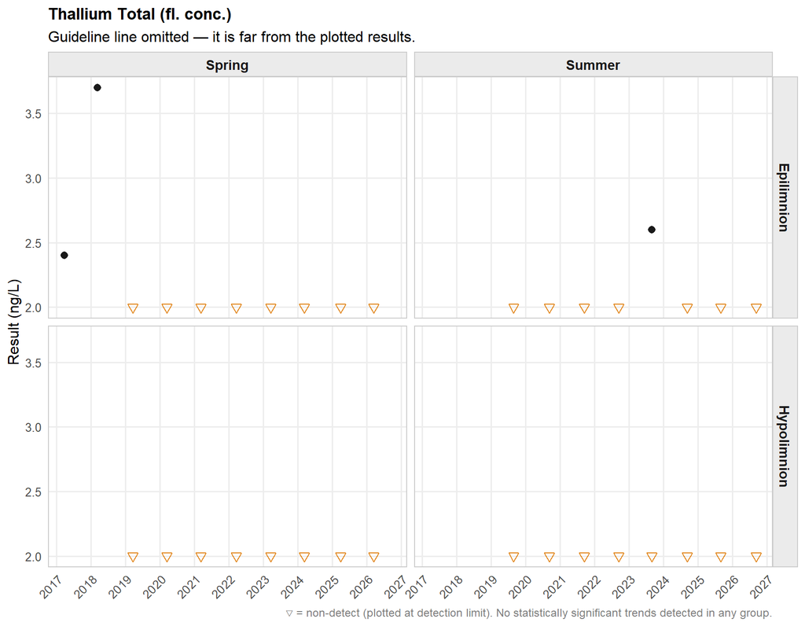

**▶ Summary Statistics Table**

**Skaha Lake**

Thallium Total (fl. conc.) (ng/L)

| N | Min<sup>1</sup> | 10th %ile | Median | Mean | 90th %ile | Max |
| --- | --- | --- | --- | --- | --- | --- |
| Hypolimnion — Summer |  |  |  |  |  |  |
| 8 | <2 | <2 | <2 | <2 | <2 | <2 |
| Hypolimnion — Spring |  |  |  |  |  |  |
| 8 | <2 | <2 | <2 | <2 | <2 | <2 |
| Epilimnion — Summer |  |  |  |  |  |  |
| 8 | <2 | <2 | <2 | 2.08 | 2.18 | 2.6 |
| Epilimnion — Spring |  |  |  |  |  |  |
| 11 | <2 | <2 | <2 | 2.19 | 2.4 | 3.7 |

<sup>1</sup> < indicates non-detect; value shown is the detection limit.

##### Tin Total (fl. conc.)

—

No simple [BC Aquatic Life Guideline](https://www2.gov.bc.ca/gov/content?id=044DD64C7E24415D83D07430964113C9) available for this parameter

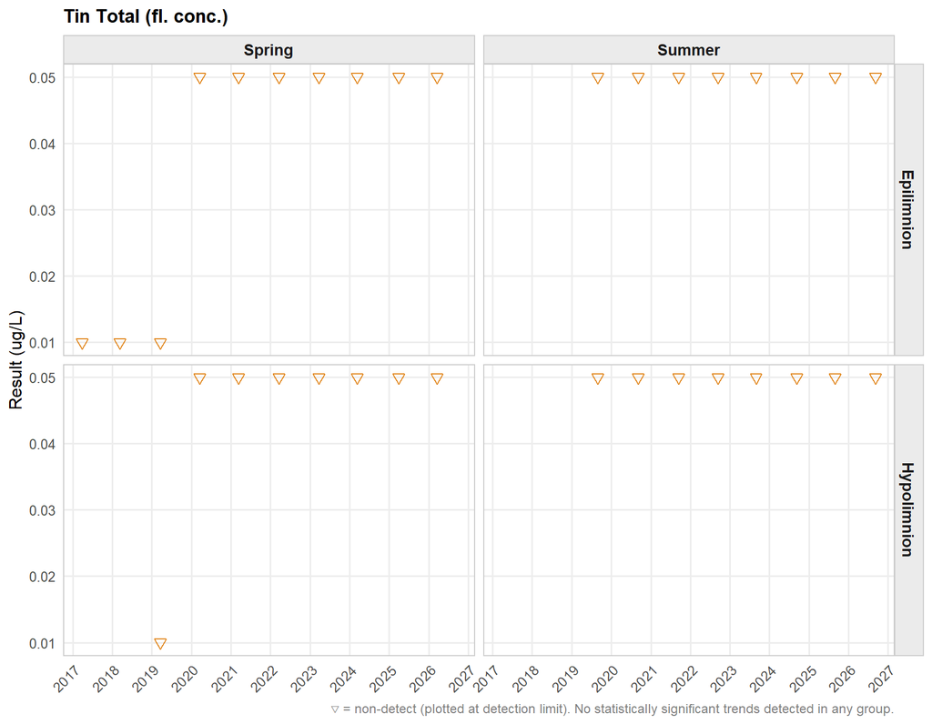

**▶ Summary Statistics Table**

**Skaha Lake**

Tin Total (fl. conc.) (ug/L)

| N | Min<sup>1</sup> | 10th %ile | Median | Mean | 90th %ile | Max |
| --- | --- | --- | --- | --- | --- | --- |
| Hypolimnion — Summer |  |  |  |  |  |  |
| 8 | 0.05 | 0.05 | 0.05 | 0.05 | 0.05 | 0.05 |
| Hypolimnion — Spring |  |  |  |  |  |  |
| 8 | <0.01 | 0.038 | 0.05 | 0.045 | 0.05 | 0.05 |
| Epilimnion — Summer |  |  |  |  |  |  |
| 8 | 0.05 | 0.05 | 0.05 | 0.05 | 0.05 | 0.05 |
| Epilimnion — Spring |  |  |  |  |  |  |
| 11 | <0.01 | <0.01 | 0.05 | 0.0391 | 0.05 | 0.05 |

<sup>1</sup> < indicates non-detect; value shown is the detection limit.

##### Uranium Total (fl. conc.)

✓

[BC Aquatic Life Guideline](https://www2.gov.bc.ca/gov/content/environment/air-land-water/water/water-quality/water-quality-guidelines/approved-water-quality-guidelines) · Long-term chronic (Upper Limit) Aquatic Life - Freshwater

≤7.5 ug/L

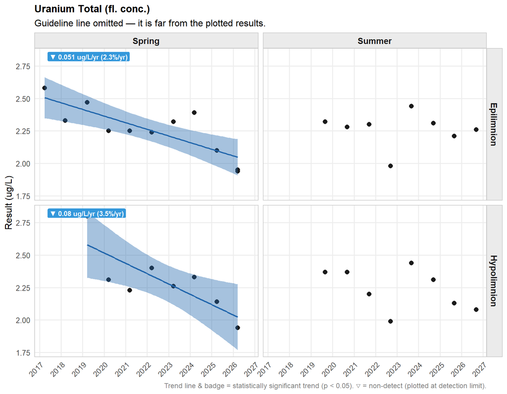

**▶ Summary Statistics Table**

**Skaha Lake**

Uranium Total (fl. conc.) (ug/L)

| N | Min<sup>1</sup> | 10th %ile | Median | Mean | 90th %ile | Max |
| --- | --- | --- | --- | --- | --- | --- |
| Hypolimnion — Summer |  |  |  |  |  |  |
| 8 | 1.99 | 2.05 | 2.26 | 2.24 | 2.39 | 2.44 |
| Hypolimnion — Spring |  |  |  |  |  |  |
| 8 | 1.94 | 2.08 | 2.28 | 2.3 | 2.52 | 2.8 |
| Epilimnion — Summer |  |  |  |  |  |  |
| 8 | 1.98 | 2.14 | 2.29 | 2.26 | 2.36 | 2.44 |
| Epilimnion — Spring |  |  |  |  |  |  |
| 11 | 1.94 | 1.95 | 2.25 | 2.26 | 2.47 | 2.58 |

<sup>1</sup> < indicates non-detect; value shown is the detection limit.

##### Vanadium Total (fl. conc.)

✓

[BC Aquatic Life Guideline](https://www2.gov.bc.ca/gov/content/environment/air-land-water/water/water-quality/water-quality-guidelines/approved-water-quality-guidelines) · Long-term chronic (Upper Limit) Aquatic Life - Freshwater

≤60 ug/L

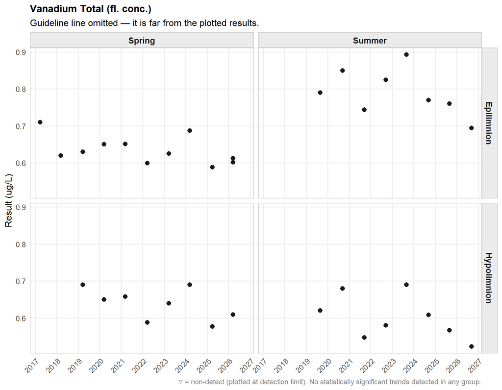

**▶ Summary Statistics Table**

**Skaha Lake**

Vanadium Total (fl. conc.) (ug/L)

| N | Min<sup>1</sup> | 10th %ile | Median | Mean | 90th %ile | Max |
| --- | --- | --- | --- | --- | --- | --- |
| Hypolimnion — Summer |  |  |  |  |  |  |
| 8 | 0.523 | 0.54 | 0.594 | 0.602 | 0.683 | 0.69 |
| Hypolimnion — Spring |  |  |  |  |  |  |
| 8 | 0.577 | 0.585 | 0.645 | 0.638 | 0.69 | 0.69 |
| Epilimnion — Summer |  |  |  |  |  |  |
| 8 | 0.694 | 0.729 | 0.78 | 0.791 | 0.863 | 0.893 |
| Epilimnion — Spring |  |  |  |  |  |  |
| 11 | 0.588 | 0.599 | 0.625 | 0.634 | 0.687 | 0.71 |

<sup>1</sup> < indicates non-detect; value shown is the detection limit.

##### Zinc Total (fl. conc.)

—

No simple [BC Aquatic Life Guideline](https://www2.gov.bc.ca/gov/content?id=044DD64C7E24415D83D07430964113C9) available for this parameter

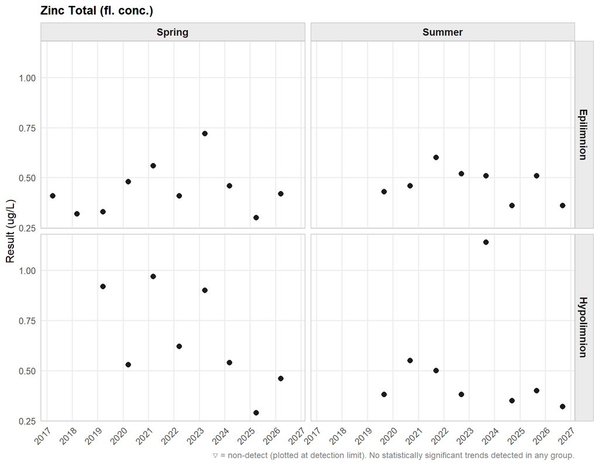

**▶ Summary Statistics Table**

**Skaha Lake**

Zinc Total (fl. conc.) (ug/L)

| N | Min<sup>1</sup> | 10th %ile | Median | Mean | 90th %ile | Max |
| --- | --- | --- | --- | --- | --- | --- |
| Hypolimnion — Summer |  |  |  |  |  |  |
| 8 | 0.32 | 0.341 | 0.39 | 0.502 | 0.727 | 1.14 |
| Hypolimnion — Spring |  |  |  |  |  |  |
| 8 | 0.29 | 0.409 | 0.58 | 0.654 | 0.935 | 0.97 |
| Epilimnion — Summer |  |  |  |  |  |  |
| 8 | 0.36 | 0.36 | 0.485 | 0.469 | 0.544 | 0.6 |
| Epilimnion — Spring |  |  |  |  |  |  |
| 11 | 0.3 | 0.32 | 0.42 | 0.439 | 0.56 | 0.72 |

<sup>1</sup> < indicates non-detect; value shown is the detection limit.

### Disclaimer

This document was produced by an automated system and has not necessarily gone through quality control checks. It is presented “as-is” with no guarantee of accuracy or completeness. Read our full [Disclaimer](https://www2.gov.bc.ca/gov/content?id=79F93E018712422FBC8E674A67A70535) for more information.